# Data Exploration using R

## Summary

The goal is to learn some approaches to understand and visualize continuous and categorical variables from the [Iris Data Set](http://archive.ics.uci.edu/ml/datasets/iris).

## Methods

These are the individual methods for measuring the central value:

- Mean
- Median
- Mode (most common value among a group)

These are the individual methods for measuring the variance or dispersion of the data:

- [Standard Deviation](https://en.wikipedia.org/wiki/Standard_deviation)
- Range
- [Quartiles](https://en.wikipedia.org/wiki/Quartile)
- [Inter Quartile Range (IQR)](https://en.wikipedia.org/wiki/Interquartile_range)
- [Coefficient of Variation](https://en.wikipedia.org/wiki/Coefficient_of_variation)

These statistical methods can be used to compare variables:

- [Correlation Coefficient](https://en.wikipedia.org/wiki/Pearson_correlation_coefficient)
- [Linear Models](https://en.wikipedia.org/wiki/Linear_model)
- [Anova](https://en.wikipedia.org/wiki/Analysis_of_variance)
- [Pearson’s chi-squared test](https://en.wikipedia.org/wiki/Pearson%27s_chi-squared_test)

## Analysis

### R libraries

We need a couple of libraries for the exercises. Let’s load them all upfront:

```r
library(ggplot2)
library(reshape2)
library(Hmisc)
library(pastecs)
```

### Calculating the mean and sd

Let’s load the data set and calculate the mean and sd of the sepal length feature.

```r
data(iris)
print(dim(iris))
```

```
## [1] 150   5
```

```r
print(head(iris))
```

```
##   Sepal.Length Sepal.Width Petal.Length Petal.Width Species
## 1          5.1         3.5          1.4         0.2  setosa
## 2          4.9         3.0          1.4         0.2  setosa
## 3          4.7         3.2          1.3         0.2  setosa
## 4          4.6         3.1          1.5         0.2  setosa
## 5          5.0         3.6          1.4         0.2  setosa
## 6          5.4         3.9          1.7         0.4  setosa
```

```r
mean(iris$Sepal.Length)
```

```
## [1] 5.843333
```

```r
sd(iris$Sepal.Length)
```

```
## [1] 0.8280661
```

### Calculating quantiles

We can also calculate the 25%, 50%, and 75% quantile of the data.

```r
quantile(iris$Sepal.Length, probs=c(0.25, 0.5, 0.75))
```

```
## 25% 50% 75%
## 5.1 5.8 6.4
```

```r
median(iris$Sepal.Length)
```

```
## [1] 5.8
```

Let’s visualize these quantiles in a histogram of sepal length.

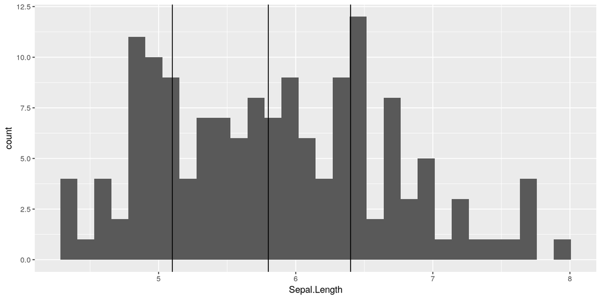

```r
ggplot(data=iris, aes(x=Sepal.Length)) + geom_histogram(bins=30) + geom_vline(xintercept=c(5.1, 5.8, 6.4))
```

Let’s do the same with a boxplot.

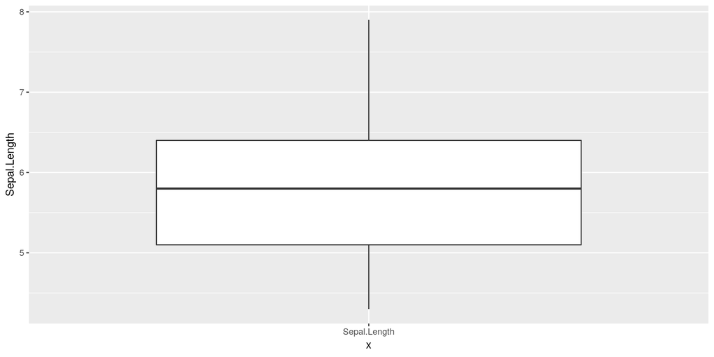

```r
ggplot(data=iris, aes(x="Sepal.Length", y=Sepal.Length)) + geom_boxplot()
```

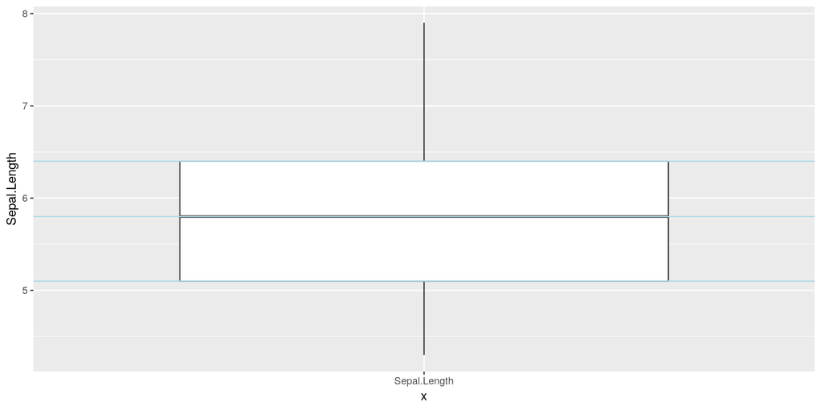

```r
ggplot(data=iris, aes(x="Sepal.Length", y=Sepal.Length)) + geom_boxplot() + geom_hline(yintercept=c(5.1, 5.8, 6.4), color="lightblue")
```

### Summarizing all features (columns)

R has many useful summary functions that include mean, sd and other statistics.

```r
print(summary(iris))
```

```
##   Sepal.Length    Sepal.Width     Petal.Length    Petal.Width
##  Min.   :4.300   Min.   :2.000   Min.   :1.000   Min.   :0.100
##  1st Qu.:5.100   1st Qu.:2.800   1st Qu.:1.600   1st Qu.:0.300
##  Median :5.800   Median :3.000   Median :4.350   Median :1.300
##  Mean   :5.843   Mean   :3.057   Mean   :3.758   Mean   :1.199
##  3rd Qu.:6.400   3rd Qu.:3.300   3rd Qu.:5.100   3rd Qu.:1.800
##  Max.   :7.900   Max.   :4.400   Max.   :6.900   Max.   :2.500
##        Species
##  setosa    :50
##  versicolor:50
##  virginica :50
##
##
##
```

```r
print(describe(iris))
```

```
## iris
##
##  5  Variables      150  Observations
## ---------------------------------------------------------------------------
## Sepal.Length
##        n  missing distinct     Info     Mean      Gmd      .05      .10
##      150        0       35    0.998    5.843   0.9462    4.600    4.800
##      .25      .50      .75      .90      .95
##    5.100    5.800    6.400    6.900    7.255
##
## lowest : 4.3 4.4 4.5 4.6 4.7, highest: 7.3 7.4 7.6 7.7 7.9
## ---------------------------------------------------------------------------
## Sepal.Width
##        n  missing distinct     Info     Mean      Gmd      .05      .10
##      150        0       23    0.992    3.057   0.4872    2.345    2.500
##      .25      .50      .75      .90      .95
##    2.800    3.000    3.300    3.610    3.800
##
## lowest : 2.0 2.2 2.3 2.4 2.5, highest: 3.9 4.0 4.1 4.2 4.4
## ---------------------------------------------------------------------------
## Petal.Length
##        n  missing distinct     Info     Mean      Gmd      .05      .10
##      150        0       43    0.998    3.758    1.979     1.30     1.40
##      .25      .50      .75      .90      .95
##     1.60     4.35     5.10     5.80     6.10
##
## lowest : 1.0 1.1 1.2 1.3 1.4, highest: 6.3 6.4 6.6 6.7 6.9
## ---------------------------------------------------------------------------
## Petal.Width
##        n  missing distinct     Info     Mean      Gmd      .05      .10
##      150        0       22     0.99    1.199   0.8676      0.2      0.2
##      .25      .50      .75      .90      .95
##      0.3      1.3      1.8      2.2      2.3
##
## lowest : 0.1 0.2 0.3 0.4 0.5, highest: 2.1 2.2 2.3 2.4 2.5
## ---------------------------------------------------------------------------
## Species
##        n  missing distinct
##      150        0        3
##
## Value          setosa versicolor  virginica
## Frequency          50         50         50
## Proportion      0.333      0.333      0.333
## ---------------------------------------------------------------------------
```

```r
print(pastecs::stat.desc(iris))
```

```
##              Sepal.Length  Sepal.Width Petal.Length  Petal.Width Species
## nbr.val      150.00000000 150.00000000  150.0000000 150.00000000      NA
## nbr.null       0.00000000   0.00000000    0.0000000   0.00000000      NA
## nbr.na         0.00000000   0.00000000    0.0000000   0.00000000      NA
## min            4.30000000   2.00000000    1.0000000   0.10000000      NA
## max            7.90000000   4.40000000    6.9000000   2.50000000      NA
## range          3.60000000   2.40000000    5.9000000   2.40000000      NA
## sum          876.50000000 458.60000000  563.7000000 179.90000000      NA
## median         5.80000000   3.00000000    4.3500000   1.30000000      NA
## mean           5.84333333   3.05733333    3.7580000   1.19933333      NA
## SE.mean        0.06761132   0.03558833    0.1441360   0.06223645      NA
## CI.mean.0.95   0.13360085   0.07032302    0.2848146   0.12298004      NA
## var            0.68569351   0.18997942    3.1162779   0.58100626      NA
## std.dev        0.82806613   0.43586628    1.7652982   0.76223767      NA
## coef.var       0.14171126   0.14256420    0.4697441   0.63555114      NA
```

With the help of ggplot2 we can visualize all features based on the outcome variable “Species”.

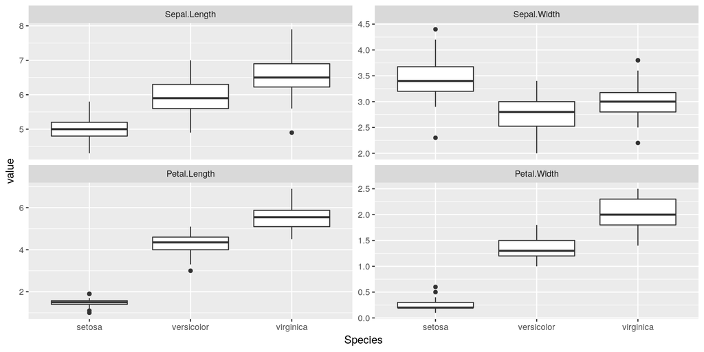

```r
lf = melt(iris, id=c("Species"))
ggplot(data=lf, aes(x=Species, y=value)) + geom_boxplot(aes(group=Species)) + facet_wrap(~variable, scales="free_y")
```

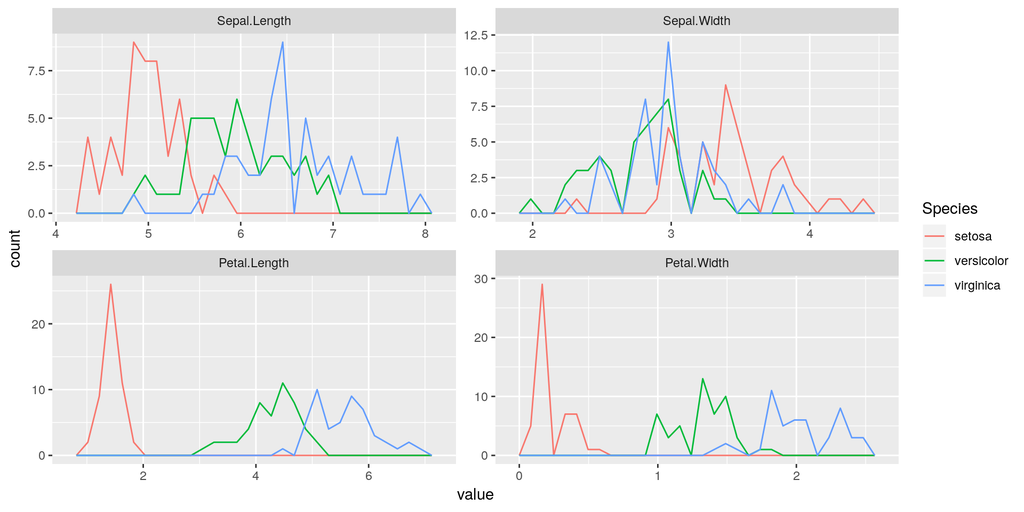

```r
ggplot(data=lf, aes(x=value)) + geom_freqpoly(aes(group=Species, color=Species), stat="bin", bins=30) + facet_wrap(~variable, scales="free")
```

### Comparing two variables (features)

Scatter plots are useful to investigate the relationship between two variables.

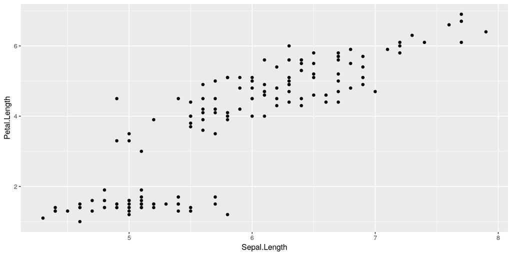

```r
ggplot(data=iris, aes(x=Sepal.Length, y=Petal.Length)) + geom_point()
```

You can stratify the scatter plot by the Species variable using facet_wrap.

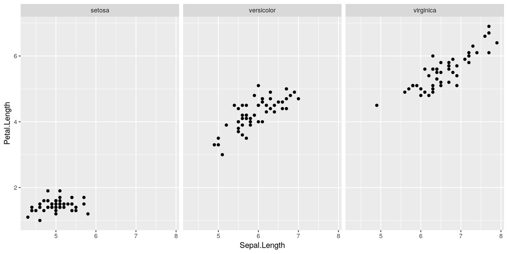

```r
ggplot(data=iris, aes(x=Sepal.Length, y=Petal.Length)) + geom_point() + facet_wrap(~Species)
```

Let’s fit a linear model to get the linear relationship between sepal length and petal length.

```r
lm(Petal.Length ~ Sepal.Length, data=iris)
```

```
##
## Call:
## lm(formula = Petal.Length ~ Sepal.Length, data = iris)
##
## Coefficients:
##  (Intercept)  Sepal.Length
##       -7.101         1.858
```

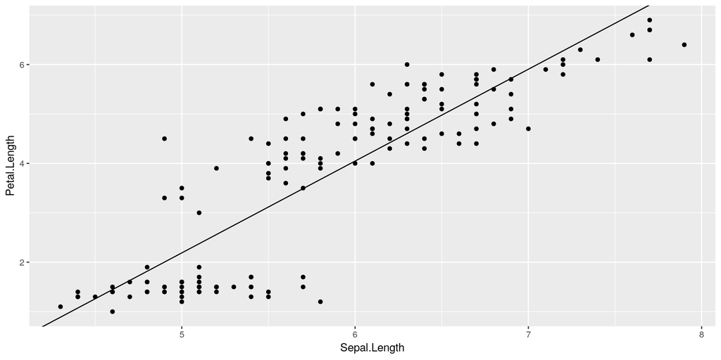

```r
ggplot(data=iris, aes(x=Sepal.Length, y=Petal.Length)) + geom_point() + geom_abline(slope=1.858, intercept=-7.101)
```

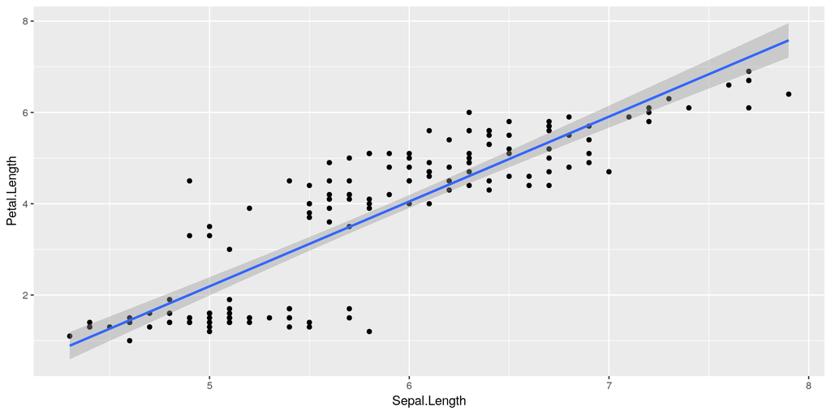

```r
ggplot(data=iris, aes(x=Sepal.Length, y=Petal.Length)) + geom_point() + geom_smooth(method="lm")
```

We can check the correlation between sepal length and petal length.

```r
cor(iris$Sepal.Length, iris$Petal.Length)
```

```
## [1] 0.8717538
```

```r
cor.test(iris$Sepal.Length, iris$Petal.Length)
```

```
##
##  Pearson's product-moment correlation
##
## data:  iris$Sepal.Length and iris$Petal.Length
## t = 21.646, df = 148, p-value < 2.2e-16
## alternative hypothesis: true correlation is not equal to 0
## 95 percent confidence interval:
##  0.8270363 0.9055080
## sample estimates:
##       cor
## 0.8717538
```

To compare a categorical variable with a continuous variable we can use a boxplot.

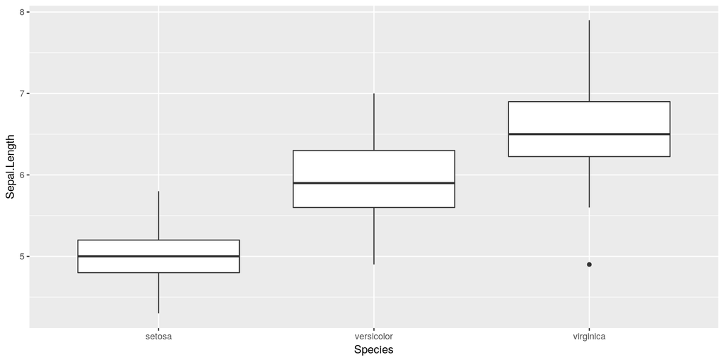

```r
ggplot(data=iris, aes(x=Species, y=Sepal.Length)) + geom_boxplot()
```

We can use [Anova](https://en.wikipedia.org/wiki/Analysis_of_variance) to find out whether all species have the same mean or if at least one species has a different mean for sepal length.

```r
av=aov(Sepal.Length ~ Species, data=iris)
print(summary(av))
```

```
##              Df Sum Sq Mean Sq F value Pr(>F)
## Species       2  63.21  31.606   119.3 <2e-16 ***
## Residuals   147  38.96   0.265
## ---
## Signif. codes:  0 '***' 0.001 '**' 0.01 '*' 0.05 '.' 0.1 ' ' 1
```

Finally, we may want to compare two categorical variables. Let’s create an artificial categorical variable Petal.Width.Bin with 4 levels.

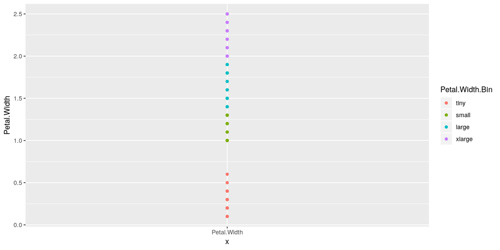

```r
iris$Petal.Width.Bin = cut(iris$Petal.Width, breaks=4, labels=c("tiny", "small", "large", "xlarge"))
iris$Petal.Width.Bin = factor(iris$Petal.Width.Bin)
ggplot(data=iris, aes(x="Petal.Width", y=Petal.Width)) + geom_point(aes(color=Petal.Width.Bin))
```

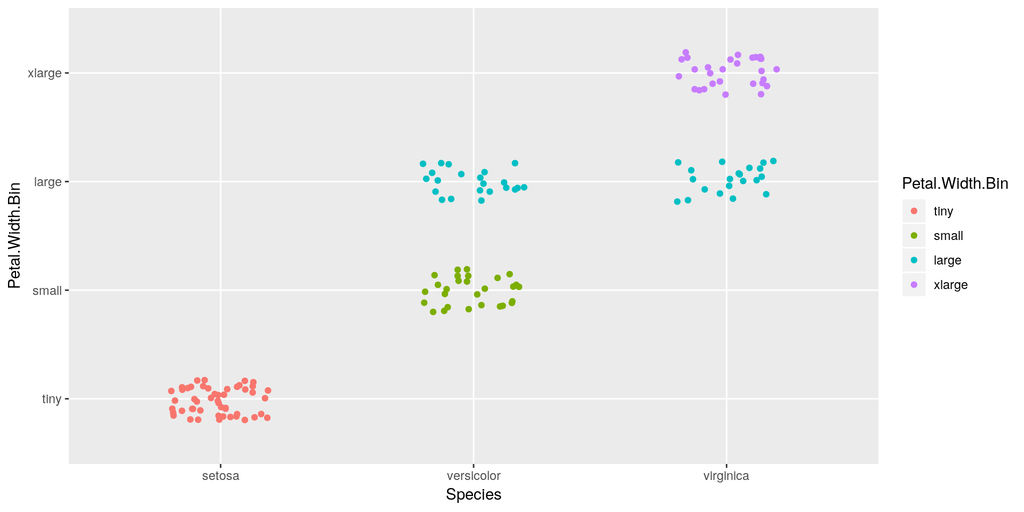

```r
ggplot(data=iris, aes(x=Species, y=Petal.Width.Bin)) + geom_jitter(aes(color=Petal.Width.Bin), width=0.2, height=0.2)
```

We can then use [Pearson’s chi-squared test](https://en.wikipedia.org/wiki/Pearson%27s_chi-squared_test) to find out if all the differences between the categories arose by chance.

```r
chisq.test(x=iris$Species, y=iris$Petal.Width.Bin)
```

```
##
##  Pearson's Chi-squared test
##
## data:  iris$Species and iris$Petal.Width.Bin
## X-squared = 235.53, df = 6, p-value < 2.2e-16
```

## Questions

A couple of questions for yourself to explore the data further.

- What is the inter quartile range (IQR) of petal width?
- What is the median petal width?
- What is the correlation coefficient of sepal width and petal width?
- Generate a scatter plot of petal width and sepal width.
- Stratify the scatter plot of petal width and sepal width by Species.
- Challenge: What is the correlation coefficient of sepal width and petal width for each Species separately?